# Case Study 4: Reducing Gun Deaths

Author

Austin Mangelson

## FiveThirtyEight Report on Gun Deaths

FiveThirtyEight, a leader in data-driven analysis, released a [report on gun deaths in America](https://fivethirtyeight.com/features/gun-deaths/) in 2016. In this, they reported 33,000 annual gun deaths in America, of which:

- Roughly two-thirds were suicides (85% male, 50% over 45 years old)
- About one-third were homicides (50%+ young men, 60% African-American)

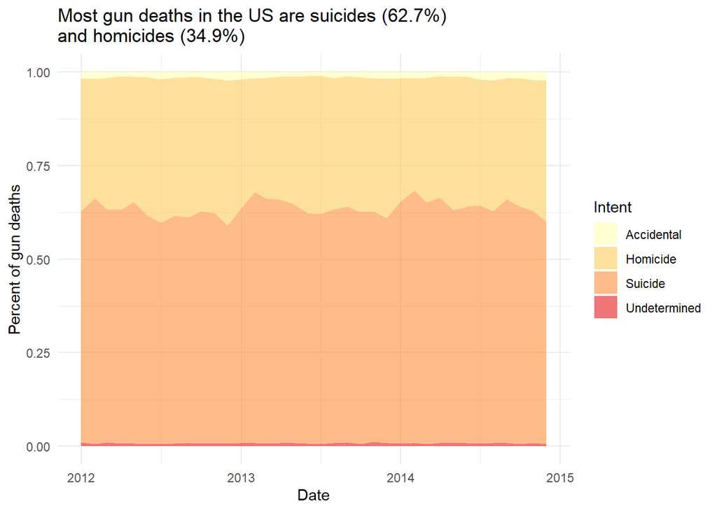

```r
gun_deaths_count <-
  gun_deaths |>
  mutate(date = make_date(year, month), .after = 3) |>
  group_by(date, intent) |>
  summarise(count = table(intent))

#plot intent area over time
ggplot(gun_deaths_count, aes(x = date, fill = intent)) +
  geom_area(alpha = 0.6, mapping = aes(y = count), position = "fill") +
  scale_fill_brewer(palette = "YlOrRd") +
  labs(
    title = "Most gun deaths in the US are suicides (62.7%) \nand homicides (34.9%)",
    x = "Date",
    y = "Percent of gun deaths",
    fill = "Intent"
  ) +
  theme_minimal()
```

## Gun Deaths by Season

My goal with this report is to aid my client in creating commercials that help reduce gun deaths in the US. These commercials will be targeted for different seasons of the year to audiences that could have the most impact in reducing gun deaths.

To start, let’s take a look at the best time of year to run these commercials.

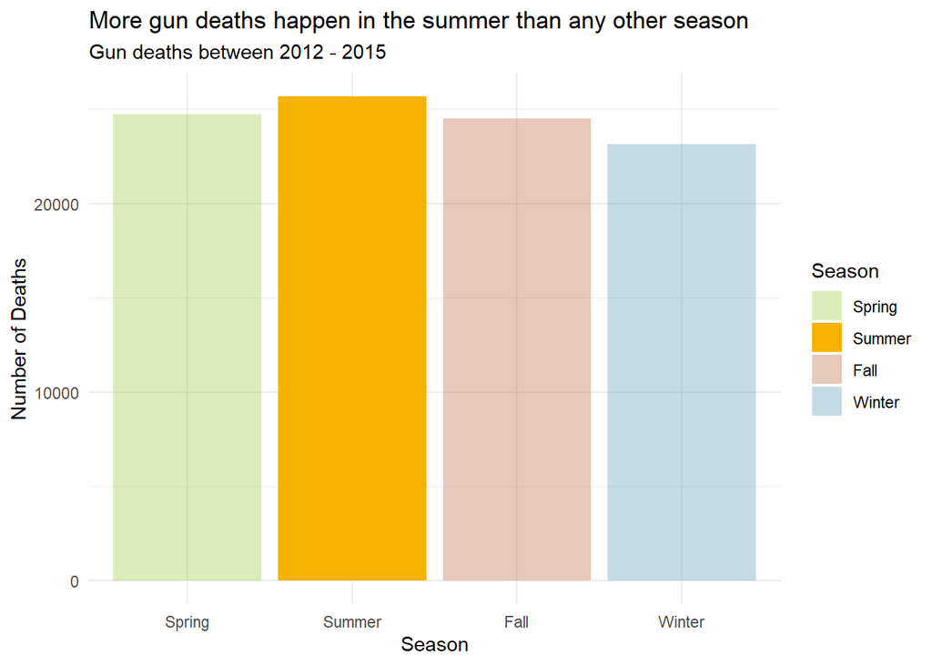

```r
gun_deaths_seasons <-
  gun_deaths |>
  mutate(season = case_when(
    month == "03" ~ "Spring",
    month == "04" ~ "Spring",
    month == "05" ~ "Spring",
    month == "06" ~ "Summer",
    month == "07" ~ "Summer",
    month == "08" ~ "Summer",
    month == "09" ~ "Fall",
    month == "10" ~ "Fall",
    month == "11" ~ "Fall",
    month == "12" ~ "Winter",
    month == "01" ~ "Winter",
    month == "02" ~ "Winter",
  )) |>
  na.omit()

season_order <- c("Spring", "Summer", "Fall", "Winter")
gun_deaths_seasons$season <- factor(gun_deaths_seasons$season, levels = season_order)
color_values <- c("#97C63A", "#F5B202", "#BB623E", "#5F99B5")
alpha_values <- c(0.35, 1, 0.35, 0.35)

ggplot(gun_deaths_seasons, aes(x = factor(season, levels = season_order), fill = season)) +
  geom_bar() +
  scale_fill_manual(values = alpha(color_values, alpha_values)) +
  labs(
    title = "More gun deaths happen in the summer than any other season",
    subtitle = "Gun deaths between 2012 - 2015",
    x = "Season",
    y = "Number of Deaths",
    fill = "Season"
  ) +
  theme_minimal()
```

This graph reveals that summer has the highest number of gun deaths compared to spring, fall, and winter. How does this trend hold up against the different causes of gun deaths?

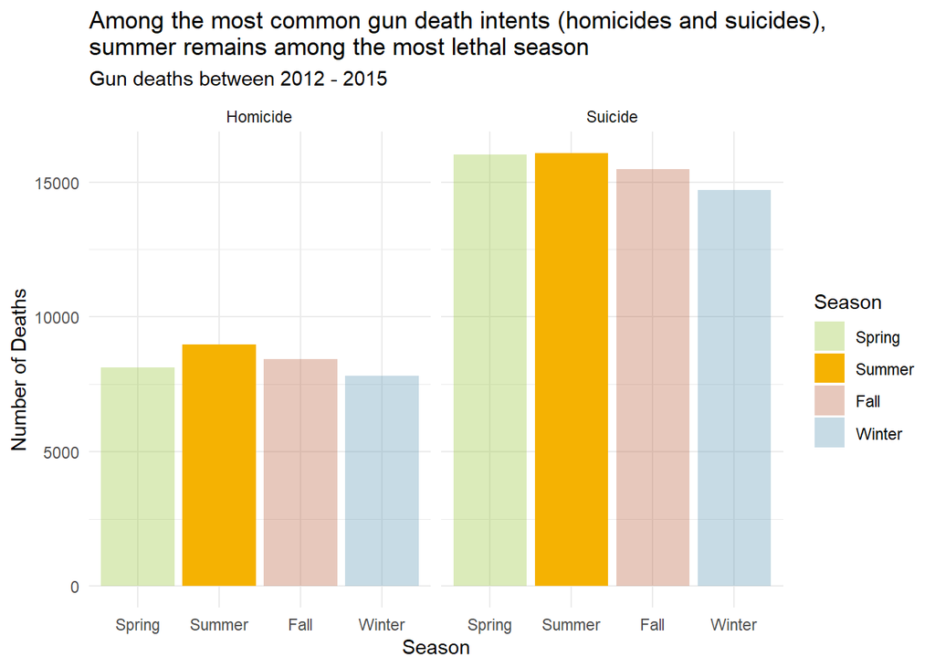

```r
gun_deaths_subset <- subset(gun_deaths_seasons, intent %in% c("Suicide", "Homicide"))
#gun_deaths_subset$intent <- factor(gun_deaths_subset$intent, levels = c("Homicide", "Suicide"))

ggplot(gun_deaths_subset, aes(x = factor(season), fill = season)) +
  geom_bar() +
  scale_fill_manual(values = alpha(color_values, alpha_values)) +
  labs(
    title = "Among the most common gun death intents (homicides and suicides), \nsummer remains among the most lethal season",
    subtitle = "Gun deaths between 2012 - 2015",
    x = "Season",
    y = "Number of Deaths",
    fill = "Season"
  ) +
  facet_wrap(~ intent) +
  theme_minimal()
```

As it turns out, among the two highest causes of gun death (homicide and suicide), gun deaths remain the highest during the summer months.

## Gun Deaths by Demographic

We’ve learned that most gun deaths are either homicides (*34.9%*) or suicides (*62.7%*), and that summer is the most common month for these deaths to occur. But what can we learn about the demographics of those deaths?

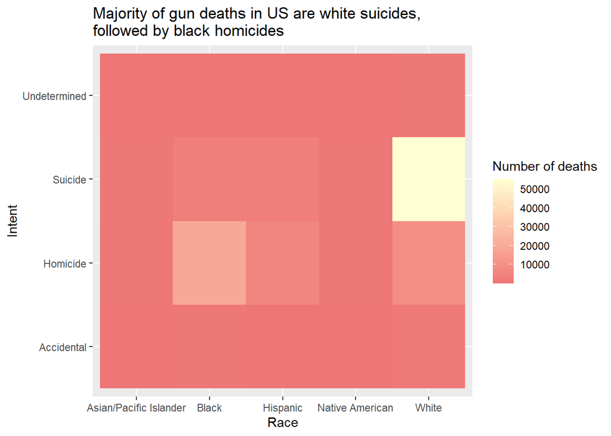

```r
race_intent_summary <-
  gun_deaths |>
  group_by(intent, race) |>
  summarise(count = n()) |>
  mutate(race = ifelse(race == "Native American/Native Alaskan", "Native American", race)) |>
  na.omit()

ggplot(race_intent_summary, aes(x = race, y = intent)) +
  geom_tile(mapping = aes(fill = count)) +
  scale_fill_gradient(low = "#EE7677", high = "#FFFFD1") +
  #scale_fill_gradient(low = "darkred", high = "lightyellow") +
  #scale_fill_brewer(palette = "Reds") +
  labs(
    title = "Majority of gun deaths in US are white suicides, \nfollowed by black homicides",
    x = "Race",
    y = "Intent",
    fill = "Number of deaths"
  )
```

It’s interesting to note here that the distribution of homicides and suicides are not equal among different races. By far, the majority of gun deaths are a result of white suicides, followed next by black homicides.

Can we take a closer look at these subgroups of people to learn a bit more about them?

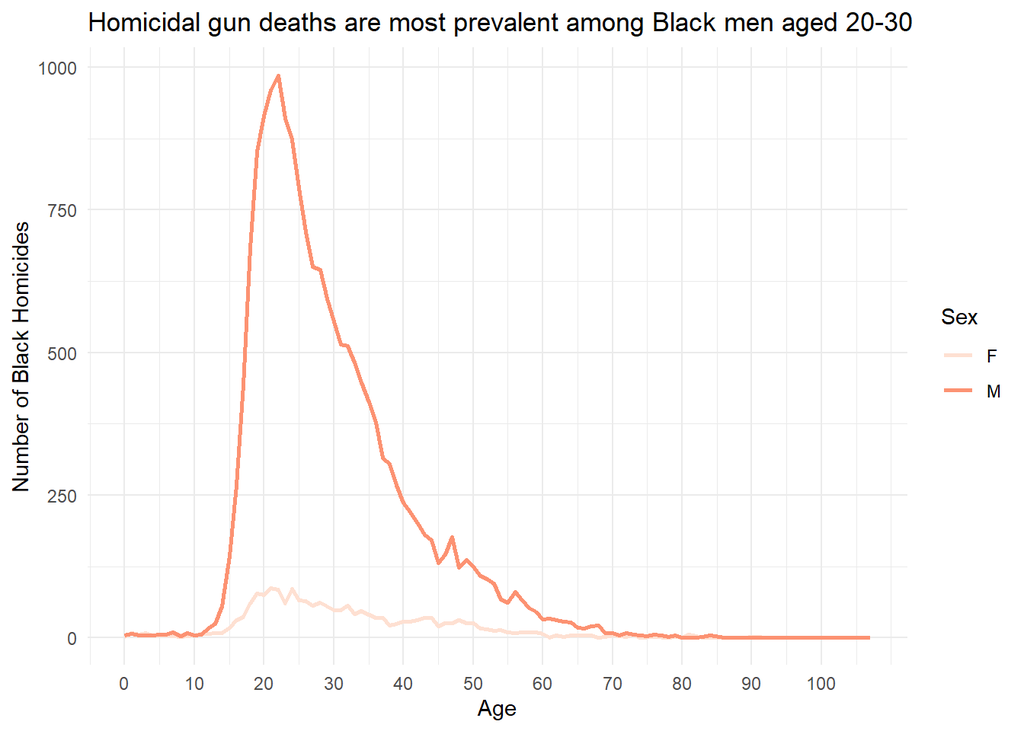

```r
black_homicides <-
  gun_deaths |>
  filter(intent == "Homicide" & race == "Black") |>
  group_by(age, sex) |>
  summarise(count = n()) |>
  na.omit()

ggplot(black_homicides, aes(x = age, y = count, color = sex)) +
  geom_line(linewidth = 1) +
  scale_color_brewer(palette = "Reds") +
  scale_x_continuous(breaks = seq(0, 100, by = 10)) +
  labs(title = "Homicidal gun deaths are most prevalent among Black men aged 20-30",
       x = "Age",
       y = "Number of Black Homicides",
       color = "Sex") +
  theme_minimal()
```

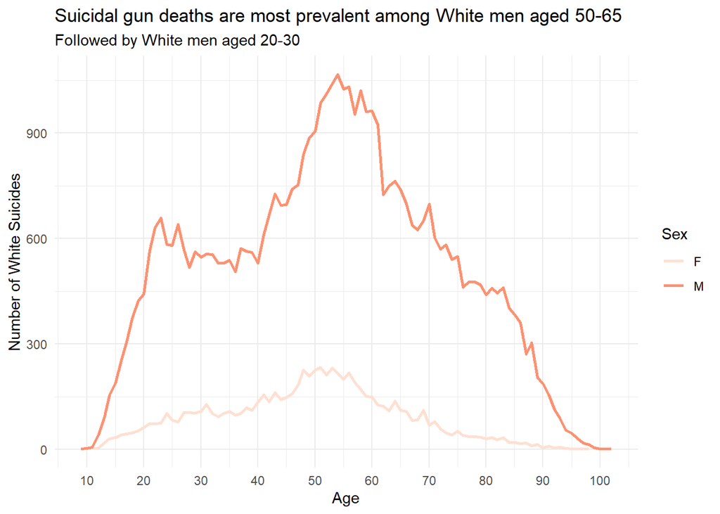

```r
white_suicides <-
  gun_deaths |>
  filter(intent == "Suicide" & race == "White") |>
  group_by(age, sex) |>
  summarise(count = n()) |>
  na.omit()

ggplot(white_suicides, aes(x = age, y = count, color = sex)) +
  geom_line(linewidth = 1) +
  scale_color_brewer(palette = "Reds") +
  scale_x_continuous(breaks = seq(0, 100, by = 10)) +
  labs(title = "Suicidal gun deaths are most prevalent among White men aged 50-65",
       subtitle = "Followed by White men aged 20-30",
       x = "Age",
       y = "Number of White Suicides",
       color = "Sex") +
  theme_minimal()
```

## Conclusion

In order to create an effective commercial campaign that has the highest chance of success in decreasing gun deaths in the US, we’ve taken a look at the common seasons for gun deaths, intents, as well as the demographics of those most at risk.

**An effective commercial campaign will target suicide among White men aged 50-65 years old, homicide among Black men aged 20-30 years old, and should be pushed most heavily during the summer months.**